# Communicate Data findings Project - Abdullah Al-Weheid

## Introduction:

> I've chhose Ford GoBike Dataset to apply the knowledge on it. I choosed this dataset for many reasons one of them is letaed to mu country. We don't have some sharing bikes system like this but in fututre and when the Metro government project will be on he land we need some systems and services like this.

> This dataset describe the data of a public bicycle sharing system called Ford GoBike contains several details about each trip on the bike such as start_station and the duration of the trip.

## Loading the data:

```python
import pandas as pd
import numpy as np
import matplotlib.pyplot as plt
import seaborn as sns

%matplotlib inline
```

```python
dfbike = pd.read_csv('201904-fordgobike-tripdata.csv',sep=";")
```

```python
dfbike.head()
```

|  | duration_sec | start_time | end_time | start_station_id | start_station_name | start_station_latitude | start_station_longitude | end_station_id | end_station_name | end_station_latitude | end_station_longitude | bike_id | user_type | bike_share_for_all_trip |
| --- | --- | --- | --- | --- | --- | --- | --- | --- | --- | --- | --- | --- | --- | --- |
| 0 | 50305 | 2019-04-30 22:33:55.1550 | 2019-05-01 12:32:20.4540 | 368.0 | Myrtle St at Polk St | 37.785434 | -122.419622 | 324.0 | Union Square (Powell St at Post St) | 37.788300 | -122.408531 | 2749 | Subscriber | No |
| 1 | 53725 | 2019-04-30 20:43:41.6320 | 2019-05-01 11:39:06.9170 | 246.0 | Berkeley Civic Center | 37.869060 | -122.270556 | 241.0 | Ashby BART Station | 37.852477 | -122.270213 | 2608 | Customer | No |
| 2 | 78072 | 2019-04-30 10:32:46.4890 | 2019-05-01 08:13:58.9750 | 64.0 | 5th St at Brannan St | 37.776754 | -122.399018 | 64.0 | 5th St at Brannan St | 37.776754 | -122.399018 | 258 | Subscriber | No |
| 3 | 78969 | 2019-04-30 10:00:51.5500 | 2019-05-01 07:57:01.2620 | 67.0 | San Francisco Caltrain Station 2 (Townsend St... | 37.776639 | -122.395526 | 89.0 | Division St at Potrero Ave | 37.769218 | -122.407646 | 1974 | Subscriber | No |
| 4 | 1128 | 2019-04-30 23:59:04.7390 | 2019-05-01 00:17:53.0910 | 124.0 | 19th St at Florida St | 37.760447 | -122.410807 | 5.0 | Powell St BART Station (Market St at 5th St) | 37.783899 | -122.408445 | 877 | Subscriber | No |

```python
dfbike.info()
```

```
<class 'pandas.core.frame.DataFrame'>
RangeIndex: 239111 entries, 0 to 239110
Data columns (total 14 columns):
duration_sec               239111 non-null int64
start_time                 239111 non-null object
end_time                   239111 non-null object
start_station_id           239047 non-null float64
start_station_name         239047 non-null object
start_station_latitude     239111 non-null float64
start_station_longitude    239111 non-null float64
end_station_id             239047 non-null float64
end_station_name           239047 non-null object
end_station_latitude       239111 non-null float64
end_station_longitude      239111 non-null float64
bike_id                    239111 non-null int64
user_type                  239111 non-null object
bike_share_for_all_trip    239111 non-null object
dtypes: float64(6), int64(2), object(6)
memory usage: 25.5+ MB
```

```python
dfbike.isnull().sum()
```

```
duration_sec                0
start_time                  0
end_time                    0
start_station_id           64
start_station_name         64
start_station_latitude      0
start_station_longitude     0
end_station_id             64
end_station_name           64
end_station_latitude        0
end_station_longitude       0
bike_id                     0
user_type                   0
bike_share_for_all_trip     0
dtype: int64
```

- we can see that there is 64 null values of start and end stations' name and id
- So delete them to make it clean

```python
dfbike = dfbike.dropna()
```

```python
dfbike.isnull().sum()
```

```
duration_sec               0
start_time                 0
end_time                   0
start_station_id           0
start_station_name         0
start_station_latitude     0
start_station_longitude    0
end_station_id             0
end_station_name           0
end_station_latitude       0
end_station_longitude      0
bike_id                    0
user_type                  0
bike_share_for_all_trip    0
dtype: int64
```

### Check The duplication:

```python
dfbike.duplicated().sum()
```

```
0
```

- That is nice, we don't have neither missing values nor duplicated rows

### Check the types of columns:

```python
dfbike.info()
```

```
<class 'pandas.core.frame.DataFrame'>
Int64Index: 239047 entries, 0 to 239110
Data columns (total 14 columns):
duration_sec               239047 non-null int64
start_time                 239047 non-null object
end_time                   239047 non-null object
start_station_id           239047 non-null float64
start_station_name         239047 non-null object
start_station_latitude     239047 non-null float64
start_station_longitude    239047 non-null float64
end_station_id             239047 non-null float64
end_station_name           239047 non-null object
end_station_latitude       239047 non-null float64
end_station_longitude      239047 non-null float64
bike_id                    239047 non-null int64
user_type                  239047 non-null object
bike_share_for_all_trip    239047 non-null object
dtypes: float64(6), int64(2), object(6)
memory usage: 27.4+ MB
```

> - We can see that there are some issues in type of time and we can generate the days of each trip from it

```python
dfbike.start_time = pd.to_datetime(dfbike['start_time'])
dfbike.end_time = pd.to_datetime(dfbike['end_time'])
```

```python
dayOfWeek={0:'Mon', 1:'Tue', 2:'Wed', 3:'Thu', 4:'Fri', 5:'Sat', 6:'Sun'}
dfbike['Day_of_trip'] = dfbike['start_time'].dt.dayofweek.map(dayOfWeek)
```

```python
listOfWeekday = ['Mon','Tue','Wed','Thu','Fri']
dfbike['Weekend'] = dfbike['Day_of_trip'].apply(lambda x: 0 if x in listOfWeekday else 1)
```

```python
dfbike.head()
```

|  | duration_sec | start_time | end_time | start_station_id | start_station_name | start_station_latitude | start_station_longitude | end_station_id | end_station_name | end_station_latitude | end_station_longitude | bike_id | user_type | bike_share_for_all_trip | Day_of_trip | WeekDay | Weekend |
| --- | --- | --- | --- | --- | --- | --- | --- | --- | --- | --- | --- | --- | --- | --- | --- | --- | --- |
| 0 | 50305 | 2019-04-30 22:33:55.155 | 2019-05-01 12:32:20.454 | 368.0 | Myrtle St at Polk St | 37.785434 | -122.419622 | 324.0 | Union Square (Powell St at Post St) | 37.788300 | -122.408531 | 2749 | Subscriber | No | Tue | 0 | 0 |
| 1 | 53725 | 2019-04-30 20:43:41.632 | 2019-05-01 11:39:06.917 | 246.0 | Berkeley Civic Center | 37.869060 | -122.270556 | 241.0 | Ashby BART Station | 37.852477 | -122.270213 | 2608 | Customer | No | Tue | 0 | 0 |
| 2 | 78072 | 2019-04-30 10:32:46.489 | 2019-05-01 08:13:58.975 | 64.0 | 5th St at Brannan St | 37.776754 | -122.399018 | 64.0 | 5th St at Brannan St | 37.776754 | -122.399018 | 258 | Subscriber | No | Tue | 0 | 0 |
| 3 | 78969 | 2019-04-30 10:00:51.550 | 2019-05-01 07:57:01.262 | 67.0 | San Francisco Caltrain Station 2 (Townsend St... | 37.776639 | -122.395526 | 89.0 | Division St at Potrero Ave | 37.769218 | -122.407646 | 1974 | Subscriber | No | Tue | 0 | 0 |
| 4 | 1128 | 2019-04-30 23:59:04.739 | 2019-05-01 00:17:53.091 | 124.0 | 19th St at Florida St | 37.760447 | -122.410807 | 5.0 | Powell St BART Station (Market St at 5th St) | 37.783899 | -122.408445 | 877 | Subscriber | No | Tue | 0 | 0 |

```python
dfbike.query('Day_of_trip== "Sat"')
```

|  | duration_sec | start_time | end_time | start_station_id | start_station_name | start_station_latitude | start_station_longitude | end_station_id | end_station_name | end_station_latitude | end_station_longitude | bike_id | user_type | bike_share_for_all_trip | Day_of_trip | WeekDay | Weekend |
| --- | --- | --- | --- | --- | --- | --- | --- | --- | --- | --- | --- | --- | --- | --- | --- | --- | --- |
| 15965 | 65617 | 2019-04-27 22:39:00.553 | 2019-04-28 16:52:37.643 | 21.0 | Montgomery St BART Station (Market St at 2nd St) | 37.789625 | -122.400811 | 383.0 | Golden Gate Ave at Franklin St | 37.780787 | -122.421934 | 1832 | Subscriber | No | Sat | 1 | 1 |
| 16229 | 83878 | 2019-04-27 16:44:22.610 | 2019-04-28 16:02:20.783 | 62.0 | Victoria Manalo Draves Park | 37.777791 | -122.406432 | 64.0 | 5th St at Brannan St | 37.776754 | -122.399018 | 390 | Subscriber | No | Sat | 1 | 1 |
| 16676 | 73829 | 2019-04-27 18:07:34.687 | 2019-04-28 14:38:04.372 | 263.0 | Channing Way at San Pablo Ave | 37.862827 | -122.290230 | 244.0 | Shattuck Ave at Hearst Ave | 37.873676 | -122.268487 | 2983 | Customer | No | Sat | 1 | 1 |
| 16678 | 73837 | 2019-04-27 18:07:19.831 | 2019-04-28 14:37:57.301 | 263.0 | Channing Way at San Pablo Ave | 37.862827 | -122.290230 | 244.0 | Shattuck Ave at Hearst Ave | 37.873676 | -122.268487 | 3177 | Customer | No | Sat | 1 | 1 |
| 17915 | 39328 | 2019-04-27 23:46:12.378 | 2019-04-28 10:41:41.337 | 259.0 | Addison St at Fourth St | 37.866249 | -122.299371 | 250.0 | North Berkeley BART Station | 37.873558 | -122.283093 | 3103 | Customer | No | Sat | 1 | 1 |
| ... | ... | ... | ... | ... | ... | ... | ... | ... | ... | ... | ... | ... | ... | ... | ... | ... | ... |
| 189167 | 406 | 2019-04-06 00:06:36.240 | 2019-04-06 00:13:22.395 | 175.0 | 49th St at Telegraph Ave | 37.835946 | -122.262366 | 167.0 | College Ave at Harwood Ave | 37.848152 | -122.252160 | 5721 | Subscriber | No | Sat | 1 | 1 |
| 189170 | 631 | 2019-04-06 00:01:46.118 | 2019-04-06 00:12:17.680 | 97.0 | 14th St at Mission St | 37.768265 | -122.420110 | 70.0 | Central Ave at Fell St | 37.773311 | -122.444293 | 5939 | Subscriber | No | Sat | 1 | 1 |
| 189171 | 255 | 2019-04-06 00:07:38.268 | 2019-04-06 00:11:53.305 | 341.0 | Fountain Alley at S 2nd St | 37.336188 | -121.889277 | 305.0 | Ryland Park | 37.342725 | -121.895617 | 1034 | Subscriber | Yes | Sat | 1 | 1 |
| 189172 | 256 | 2019-04-06 00:07:35.878 | 2019-04-06 00:11:52.863 | 341.0 | Fountain Alley at S 2nd St | 37.336188 | -121.889277 | 305.0 | Ryland Park | 37.342725 | -121.895617 | 4043 | Subscriber | Yes | Sat | 1 | 1 |
| 189174 | 330 | 2019-04-06 00:05:54.518 | 2019-04-06 00:11:25.150 | 108.0 | 16th St Mission BART | 37.764710 | -122.419957 | 58.0 | Market St at 10th St | 37.776619 | -122.417385 | 4874 | Subscriber | No | Sat | 1 | 1 |

23056 rows × 17 columns

> I've added two columns to know on which day the trip was and based on this information see it is weekend or not weekend = 1 and weekday = 0

```python
dfbike['Trip_start_hour'] = dfbike['start_time'].dt.hour
```

```python
# ## Convert BikeId, Start_station_id and end_station_id to string
# dfbike.bike_id = dfbike.bike_id.astype(float)
# dfbike.start_station_id= dfbike.start_station_id.astype(float)
# dfbike.end_station_id = dfbike.end_station_id.astype(float)
```

```python
dfbike.head()
```

|  | duration_sec | start_time | end_time | start_station_id | start_station_name | start_station_latitude | start_station_longitude | end_station_id | end_station_name | end_station_latitude | end_station_longitude | bike_id | user_type | bike_share_for_all_trip | Day_of_trip | WeekDay | Weekend | Trip_start_hour |
| --- | --- | --- | --- | --- | --- | --- | --- | --- | --- | --- | --- | --- | --- | --- | --- | --- | --- | --- |
| 0 | 50305 | 2019-04-30 22:33:55.155 | 2019-05-01 12:32:20.454 | 368.0 | Myrtle St at Polk St | 37.785434 | -122.419622 | 324.0 | Union Square (Powell St at Post St) | 37.788300 | -122.408531 | 2749 | Subscriber | No | Tue | 0 | 0 | 22 |
| 1 | 53725 | 2019-04-30 20:43:41.632 | 2019-05-01 11:39:06.917 | 246.0 | Berkeley Civic Center | 37.869060 | -122.270556 | 241.0 | Ashby BART Station | 37.852477 | -122.270213 | 2608 | Customer | No | Tue | 0 | 0 | 20 |
| 2 | 78072 | 2019-04-30 10:32:46.489 | 2019-05-01 08:13:58.975 | 64.0 | 5th St at Brannan St | 37.776754 | -122.399018 | 64.0 | 5th St at Brannan St | 37.776754 | -122.399018 | 258 | Subscriber | No | Tue | 0 | 0 | 10 |
| 3 | 78969 | 2019-04-30 10:00:51.550 | 2019-05-01 07:57:01.262 | 67.0 | San Francisco Caltrain Station 2 (Townsend St... | 37.776639 | -122.395526 | 89.0 | Division St at Potrero Ave | 37.769218 | -122.407646 | 1974 | Subscriber | No | Tue | 0 | 0 | 10 |
| 4 | 1128 | 2019-04-30 23:59:04.739 | 2019-05-01 00:17:53.091 | 124.0 | 19th St at Florida St | 37.760447 | -122.410807 | 5.0 | Powell St BART Station (Market St at 5th St) | 37.783899 | -122.408445 | 877 | Subscriber | No | Tue | 0 | 0 | 23 |

### What is/are the main feature(s) of interest in your dataset?

> The days of which have many trips and also about the stations and trips if that were in weekends or not? and which type of customer have been used this service more than the other, i.e. who have many trips subscriber or customer?

### What features in the dataset do you think will help support your investigation into your feature(s) of interest?

> I think that these features will help me a lot
> - Trip Duration
> - User Type
> - Weekend
> - WeekDay
> - Start Station Name
> - End Station Name

## Univariate Exploration

> investigating distributions of individual variables.

```python
dfbike.describe(include = ['O'])
```

|  | start_station_name | end_station_name | user_type | bike_share_for_all_trip | Day_of_trip |
| --- | --- | --- | --- | --- | --- |
| count | 239047 | 239047 | 239047 | 239047 | 239047 |
| unique | 357 | 358 | 2 | 2 | 7 |
| top | San Francisco Caltrain Station 2 (Townsend St... | San Francisco Caltrain Station 2 (Townsend St... | Subscriber | No | Tue |
| freq | 4866 | 7115 | 203185 | 218407 | 43598 |

```
array([[<matplotlib.axes._subplots.AxesSubplot object at 0x0000020B4BFC1F60>]],
      dtype=object)
```

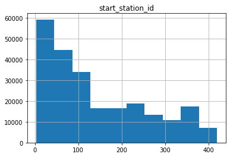

```python
dfbike.hist(column='start_station_id')
```

```
array([[<matplotlib.axes._subplots.AxesSubplot object at 0x0000020B486F14E0>]],
      dtype=object)
```

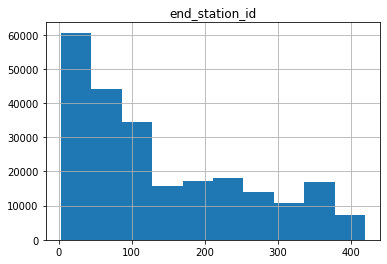

```python
dfbike.hist(column='end_station_id')
```

> we can see that stations ID between 0 - 130 has most number of trips that were taken.

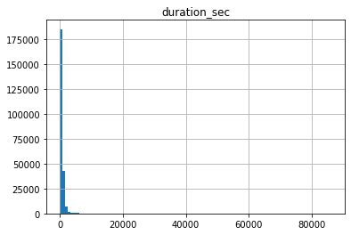

```python
dfbike.hist(column='duration_sec',bins= 100);
```

> I think there are some outliers! i will check the distribution

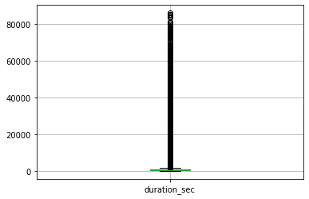

```python
dfbike.boxplot(column='duration_sec');
```

> Ammm This clea that this distribution is not normally !

```python
dfbike['duration_sec'].describe()
```

```
count    239047.000000
mean        802.448431
std        1989.807584
min          61.000000
25%         349.000000
50%         558.000000
75%         876.000000
max       86114.000000
Name: duration_sec, dtype: float64
```

> let us focus on the value distribution :

```
(0, 7000)
```

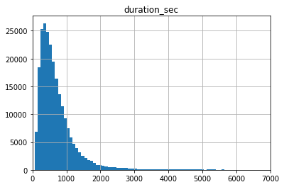

```python
dfbike.hist(column='duration_sec',bins=1000);
plt.xlim(xmin=0, xmax = 7000)
```

> I think that I'm going to check the number of outliers values and deciced if I am going to drop it or not

```python
dfbike.query('duration_sec > 3000').count()
```

```
duration_sec               3696
start_time                 3696
end_time                   3696
start_station_id           3696
start_station_name         3696
start_station_latitude     3696
start_station_longitude    3696
end_station_id             3696
end_station_name           3696
end_station_latitude       3696
end_station_longitude      3696
bike_id                    3696
user_type                  3696
bike_share_for_all_trip    3696
Day_of_trip                3696
WeekDay                    3696
Weekend                    3696
Trip_start_hour            3696
dtype: int64
```

> There are 3700 outliers vlues approximately ditributed till more than 80K!, I will convert it to minute then I will decide either keep or drop them.

```python
dfbike.duration_sec = dfbike.duration_sec/60
```

[output not shown]

```python
dfbike.rename(columns={'duration_sec':'duration_min'},inplace=True)
```

```
(0, 100)
```

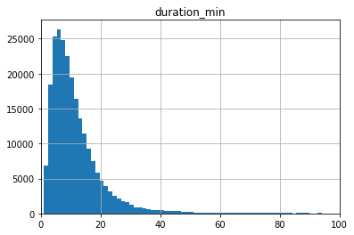

```python
dfbike.hist(column='duration_min',bins=1000);
plt.xlim(xmin=0, xmax = 100)
```

#### So I will accept the range until 100 to not missing some more values

```python
dfbike.query('duration_min > 100').count()
```

```
duration_min               1398
start_time                 1398
end_time                   1398
start_station_id           1398
start_station_name         1398
start_station_latitude     1398
start_station_longitude    1398
end_station_id             1398
end_station_name           1398
end_station_latitude       1398
end_station_longitude      1398
bike_id                    1398
user_type                  1398
bike_share_for_all_trip    1398
Day_of_trip                1398
WeekDay                    1398
Weekend                    1398
Trip_start_hour            1398
dtype: int64
```

```python
dfbike = dfbike.query('duration_min <= 100')
```

```
(0, 100)
```

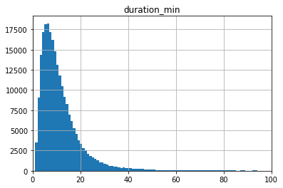

```python
dfbike.hist(column='duration_min',bins=100)
plt.xlim(xmin=0, xmax = 100)
```

#### Insight : We can see that most customer use the bike for 1 to 20 and 30 minutes

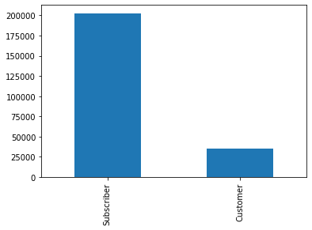

```python
dfbike['user_type'].value_counts().plot(kind='bar')
```

> Wow, It clear that most of riders are Subscribers

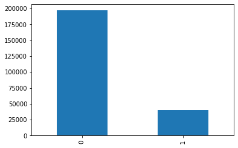

```python
dfbike['Weekend'].value_counts().plot(kind='bar');
```

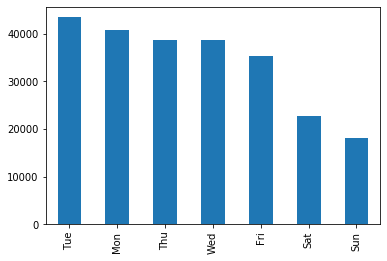

```python
dfbike['Day_of_trip'].value_counts().plot(kind='bar',);
```

> Most of the utilizaion of the bikes were in the weekdays, may be because that people try to ride a bike to go their jobs or unversities.

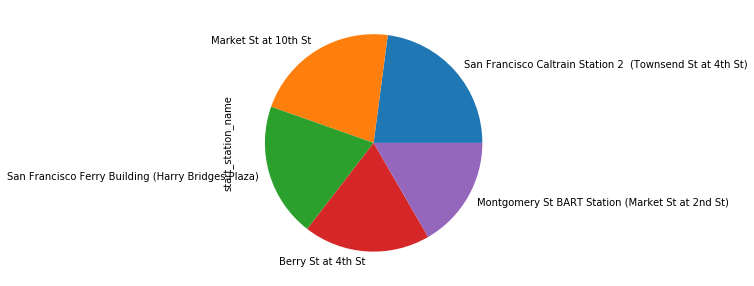

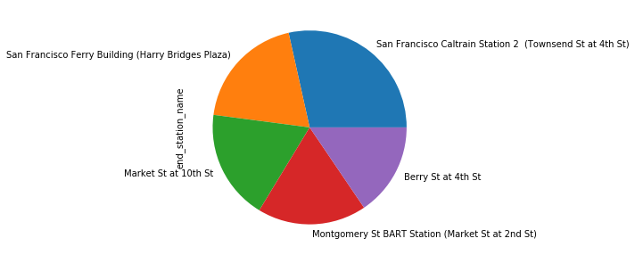

```python
plt.figure(figsize=(5,5))
dfbike['start_station_name'].value_counts().head(5).plot(kind='pie');
plt.figure(figsize=(5,5))
dfbike['end_station_name'].value_counts().head(5).plot(kind='pie');
```

> We can see that the top 5 of start_stations are also appearing in top fife of end_stations

### Discuss the distribution(s) of your variable(s) of interest. Were there any unusual points? Did you need to perform any transformations?

> No, but it was related to duration because the values was in seconds and i tried to low the range to be small so I converted it to be in minutes!

### Of the features you investigated, were there any unusual distributions? Did you perform any operations on the data to tidy, adjust, or change the form of the data? If so, why did you do this?

> Yes we saw that Duration was not in good distribution and it had many outliers spersted in big range of the concentrated data, and I tried to solve it and i think i did it well.

## Bivariate Exploration

> To start off with, I want to look at the pairwise correlations present between features in the data.

```python
numeric_vars = ['duration_min','start_station_id','start_station_latitude', 'start_station_longitude','end_station_id','end_station_latitude','end_station_longitude' ,'bike_id','Weekend']
categoric_vars = ['start_station_name', 'end_station_name', 'user_type', 'bike_share_for_all_trip', 'Day_of_trip','Trip_start_hour']
```

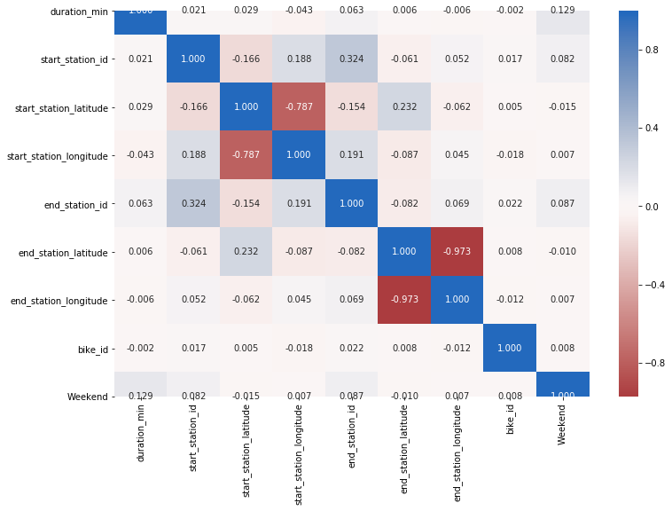

```python
# correlation plot
plt.figure(figsize = [12, 8])
sns.heatmap(dfbike[numeric_vars].corr(), annot = True, fmt = '.3f', cmap = 'vlag_r', center = 0)
plt.show()
```

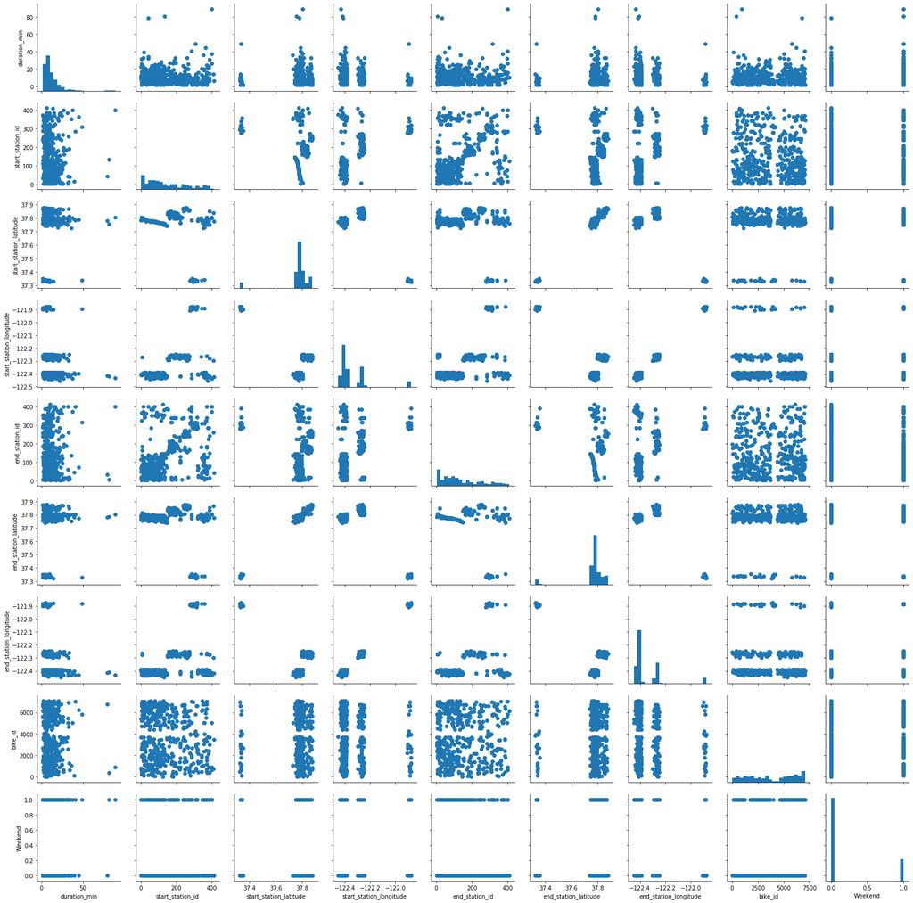

```python
# plot matrix: sample 1500 trips so that plots are clearer and
# they render faster
samples = np.random.choice(dfbike.shape[0], 500, replace = False)
trips_samp = dfbike.loc[samples,:]

g = sns.PairGrid(data = trips_samp, vars = numeric_vars)
g = g.map_diag(plt.hist, bins = 20);
g.map_offdiag(plt.scatter)
```

> This matrix of plots describe the hard of finding two related variales.

#### I will strart to find some points i want to know like, who takes more time in trips? is a subscriber or customer?

```python
most_trips_from_user = dfbike[['user_type','duration_min']].groupby(['user_type'], as_index = False).sum().sort_values(by='user_type',ascending=False)
most_trips_from_user
```

|  | user_type | duration_min |
| --- | --- | --- |
| 1 | Subscriber | 2.143397e+06 |
| 0 | Customer | 6.341461e+05 |

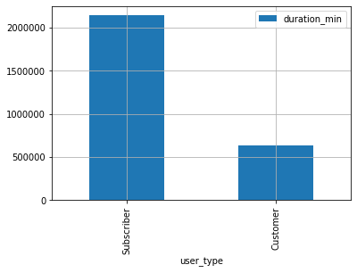

```python
most_trips_from_user.plot.bar('user_type','duration_min', grid=True);
```

```python
stations_with_many_trips = dfbike[['start_station_name','duration_min']].groupby(['start_station_name'], as_index = False).sum().sort_values(by='duration_min',ascending=False).head(5)
```

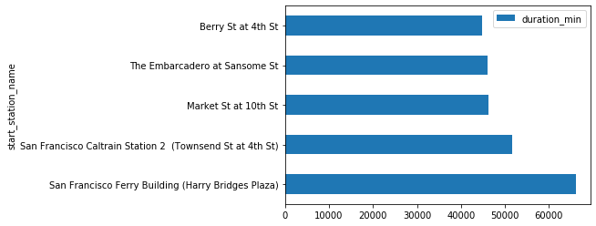

```python
stations_with_many_trips.plot.barh('start_station_name','duration_min')
```

```python
stations_in_weekend = dfbike[['start_station_name','Weekend']].groupby(['start_station_name'], as_index = False).sum().sort_values(by='Weekend',ascending=False).head(5)
```

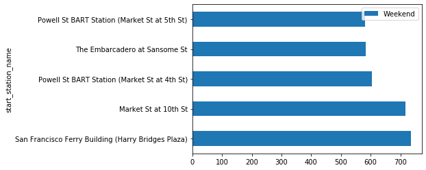

```python
stations_in_weekend.plot.barh('start_station_name','Weekend')
```

```python
Duration_in_days = dfbike[['Day_of_trip','duration_min']].groupby(['Day_of_trip'], as_index = False).sum().sort_values(by='duration_min',ascending=False)
Duration_in_days
```

|  | Day_of_trip | duration_min |
| --- | --- | --- |
| 5 | Tue | 472305.083333 |
| 1 | Mon | 443282.333333 |
| 6 | Wed | 432005.533333 |
| 4 | Thu | 431616.800000 |
| 0 | Fri | 411465.916667 |
| 2 | Sat | 326415.883333 |
| 3 | Sun | 260451.400000 |

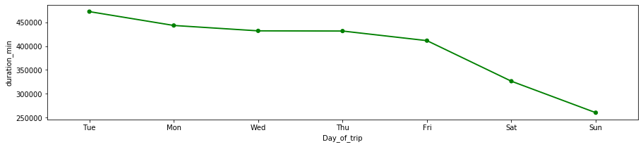

```python
plt.figure(figsize = [15, 3]);
sns.pointplot(x='Day_of_trip', y='duration_min', scale=.7, color='green', data=Duration_in_days)
```

> Days od work has most the long trips duration and we can see that Tuesday is the most day which people will take trip for long time.

### Talk about some of the relationships you observed in this part of the investigation. How did the feature(s) of interest vary with other features in the dataset?

> There are some relations which sometimes are strong or weak, we can see the relation of the work days with number of trips or their duration or between location of station and it's number of trips and duration!

### Did you observe any interesting relationships between the other features (not the main feature(s) of interest)?

> I think I can go deep in investigation and try to find prediction about which end station rider will stop at it, but i focus on duration estimation and the user type who will use the service.

## Multivariate Exploration

```python
def hist2dgrid(x, y, **kwargs):
    """ Quick hack for creating heat maps with seaborn's PairGrid. """
    palette = kwargs.pop('color')
    bins_x = np.arange(1, cdfbike['Trip_start_hour'].max()+2, 2);
    bins_y = np.arange(0, 2, 0.1);
    plt.hist2d(x, y, bins = [bins_x, bins_y], cmap = palette, cmin = 0.5)
    plt.yticks(log_trans(np.array([1, 2, 5, 10, 20, 50, 100])),
               [1, 2, 5, 10, 20, 50, 100]);
```

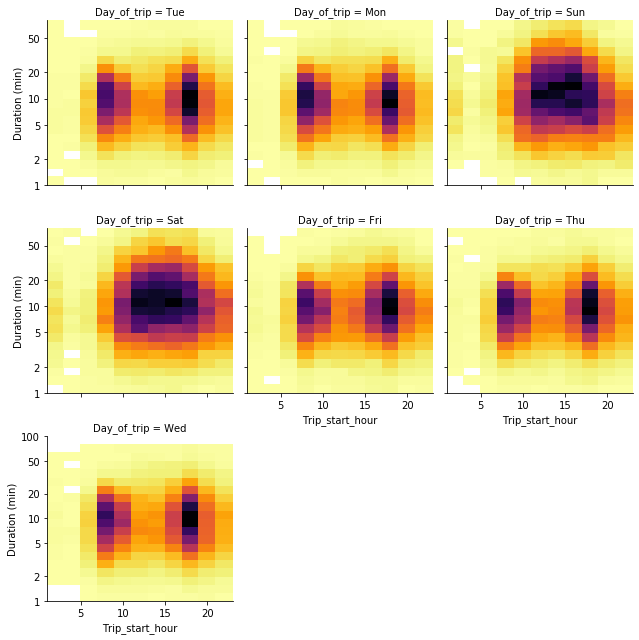

```python
# create faceted heat maps on levels of the cut variable
g = sns.FacetGrid(data = cdfbike, col = 'Day_of_trip', col_wrap = 3, height = 3);
g.map(hist2dgrid, 'Trip_start_hour', 'log_duration_min', color = 'inferno_r')
g.set_xlabels('Trip_start_hour')
g.set_ylabels('Duration (min)')
```

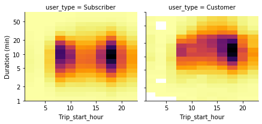

```python
# create faceted heat maps on levels of the cut variable
g = sns.FacetGrid(data = cdfbike, col = 'user_type', col_wrap = 3, height = 3);
g.map(hist2dgrid, 'Trip_start_hour', 'log_duration_min', color = 'inferno_r')
g.set_xlabels('Trip_start_hour')
g.set_ylabels('Duration (min)')
```

> Most of Subscibers come between two time intervals from 5-10 and 15 - 20 and these trips are around 3 - 20 minutes. While Customers use come in long range from 7 - 23 and take more time than subscribers.

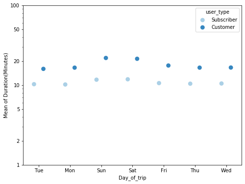

```python
fig = plt.figure(figsize = [8,6])
ax = sns.pointplot(data = cdfbike, x = 'Day_of_trip', y = 'duration_min', hue = 'user_type',
           palette = 'Blues', linestyles = '', dodge = 0.3);
plt.ylabel('Mean of Duration(Minutes)')
plt.yscale('log');
plt.yticks([1, 2, 5, 10, 20, 50, 100], [1, 2, 5, 10, 20, 50, 100]);
ax.set_yticklabels([],minor = True);
```

> At all days customers take long trip than subscribers

### Talk about some of the relationships you observed in this part of the investigation. Were there features that strengthened each other in terms of looking at your feature(s) of interest?

> I extended my investigation of duration against days of rips and who are take the trip (Subscriber or Customer) in this section by looking at the impact of the categorical quality features. The multivariate exploration here showed that there is relation between which day of trip is and who will take a trip on bike? all these variables or features can help to decide how much duration will be and how can predict the end station, but i did not try to focus on this part in this exploration.

### Were there any interesting or surprising interactions between features?

> Yes, by looking back the figures above we can see the relation between the duration, day of trip and user type, and you can see the good relation between these three variables.